# Unconstrained Multivariable Optimization

# Definisi

### *Optimization*

> Memaksimumkan / Meminimumkan sebuah fungsi dengan memilih nilai input secara sistematis dan menghitung nilai dari fungsi tersebut.

### *Unconstrained*

> Peubah yang digunakan dalam fungsi yang akan dioptimalkan tidak dibatasi nilai-nilai tertentu.

Tentu saja lawan dari *Unconstrained* adalah *Constrained*

### Multivariable

> Peubah yang digunakan untuk optimasi lebih dari satu.

## Metode

| Direct Search Method | Descent Method |
| --- | --- |
| **Random Search method** | Stepest Descent (Cauchy) Method |
| Grid Search method | Fletcher-Reeves method |
| Univariate method | Newton’s method |
| Pattern Search method | Marquardt method |
| Powels’s method | Quasi-Newton Method |
| **Simplex method** | Davidon-Flecther-Powell method |
| - | Broyden-Fletcher-Goldfarb-Shanno method |

### Direct Search Method

> Tidak menggunakan turunan dari fungsi yang akan dioptimalkan

### Descent Method

> Menggunakan turunan dari fungsi yang akan dioptimalkan.

# Random Search Method

Suatu fungsi $f(x,y)=y-x-2x^2-2xy-y^2$ yang akan dicari nilai optimalnya.

Untuk memudahkan, akan dibatasi nilai $-2 \le x \le 2$ dan $1 \le y \le 3$.

Maka akan didefinisikan terlebih dahulu fungsi $f$

```r
f <- function(x,y) {y-x-2*x^2-2*x*y-y^2}
f
```

```
## function(x,y) {y-x-2*x^2-2*x*y-y^2}
```

Pada proses `Random Search` akan dibangkitkan bilangan acak r dengan nilai $0 \le r \le 1$

```r
set.seed(16)
runif(n = 10, min = 0, max = 1)
```

```
##  [1] 0.68311006 0.24411742 0.45011136 0.22943509 0.86350792 0.31120028
##  [7] 0.07433727 0.83232161 0.87448048 0.13936174
```

Fungsi `set.seed()` digunakan untuk mengunci nilai bilangan acak yang dibangkitkan. Jika tidak digunakan maka, nilai yang dibangkitkan tiap kali menjalankan kode tersebut akan berbeda.

## Nilai Input

### Nilai input peubah x

Karena di atas dibatasi, maka bisa dibentuk fungsi baru sesuai dengan batas $-2 \le x \le 2$, yaitu

$x = x_{bawah} + (x_{atas} - x_{bawah})*r$  
$x = -2 + (2 - (-2))*r$  
$x = -2 + 4*r$

Dituliskan dalam kode R sebagai berikut :

```r
frx <- function(r) {-2+4*r}
```

### Nilai input peubah y

Karena di atas dibatasi, maka bisa dibentuk fungsi baru sesuai dengan batas $1 \le y \le 3$, yaitu

$y = y_{bawah} + (y_{atas} - y_{bawah})*r$  
$y = 1 + (3 - 1)*r$  
$y = 1 + 2*r$

Dituliskan dalam kode R sebagai berikut :

```r
fry <- function(r) {1+2*r}
```

## Pembangkitan Nilai Acak

### Membangkitkan angka acak untuk x

```r
set.seed(16)
rx <- runif(10, min = 0, max = 1)
rx
```

```
##  [1] 0.68311006 0.24411742 0.45011136 0.22943509 0.86350792 0.31120028
##  [7] 0.07433727 0.83232161 0.87448048 0.13936174
```

### Membangkitkan angka acak untuk y

```r
set.seed(32)
ry <- runif(10, min = 0, max = 1)
ry
```

```
##  [1] 0.5058405 0.5948084 0.8087471 0.7288197 0.1519876 0.9561873 0.7535377
##  [8] 0.8520623 0.6734418 0.3871255
```

## Membentuk nilai untuk input fungsi f

### Memasukkan nilai `rx` ke `frx` untuk menjadi nilai yang dimasukkan ke fungsi f

```r
x <- frx(rx)
x
```

```
##  [1]  0.7324402 -1.0235303 -0.1995546 -1.0822596  1.4540317 -0.7551989
##  [7] -1.7026509  1.3292865  1.4979219 -1.4425530
```

### Memasukkan nilai `ry` ke `fry` untuk menjadi nilai yang dimasukkan ke fungsi f

```r
y <- fry(ry)
y
```

```
##  [1] 2.011681 2.189617 2.617494 2.457639 1.303975 2.912375 2.507075 2.704125
##  [9] 2.346884 1.774251
```

Pada tahap selanjutnya, nilai yang diperoleh tersebut akan dikombinasikan untuk dimasukkan dengan fungsi $f(x,y)=y-x-2x^2-2xy-y^2$

## Random Search Method

```r
df <- NULL
```

Object `df` didefinisikan untuk menyiapkan tempat penyimpanan hasil iterasi.

```r
for (i in 1:10) {
  x = frx(ry[i])
  for (j in 1:10) {
    y = fry(ry[j])
    z = (i-1)*10+j
    df$No[z] <- z
    df$rx[z] <- rx[i]
    df$x[z] <- x
    df$ry[z] <- ry[j]
    df$y[z] <- y
    df$nilai[z] <- f(x,y)
  j = j + 1
  }
  i = i + 1
}
```

```r
df <- as.data.frame(df)
```

Fungsi `as.data.frame()` digunakan untuk membuat output iterasi yang berupa list menjadi `data frame`

Berikut adalah hasil dari Random Search di atas.

```r
df
```

```
##      No         rx           x        ry        y        nilai
## 1     1 0.68311006  0.02336209 0.5058405 2.011681  -2.15362741
## 2     2 0.68311006  0.02336209 0.5948084 2.189617  -2.73156656
## 3     3 0.68311006  0.02336209 0.8087471 2.617494  -4.38053592
## 4     4 0.68311006  0.02336209 0.7288197 2.457639  -3.72163709
## 5     5 0.68311006  0.02336209 0.1519876 1.303975  -0.48175685
## 6     6 0.68311006  0.02336209 0.9561873 2.912375  -5.73008278
## 7     7 0.68311006  0.02336209 0.7535377 2.507075  -3.91994628
## 8     8 0.68311006  0.02336209 0.8520623 2.704125  -4.75896684
## 9     9 0.68311006  0.02336209 0.6734418 2.346884  -3.29508872
## 10   10 0.68311006  0.02336209 0.3871255 1.774251  -1.48106994
## 11   11 0.24411742  0.37923355 0.5058405 2.011681  -4.22784318
## 12   12 0.24411742  0.37923355 0.5948084 2.189617  -4.93242683
## 13   13 0.24411742  0.37923355 0.8087471 2.617494  -6.88593496
## 14   14 0.24411742  0.37923355 0.7288197 2.457639  -6.11326059
```

[output cut: 86 more lines]

Langkah selanjutnya anda tinggal mengurutkan `df` di atas pada kolom `nilai`.

```r
df[order(df$nilai),]
```

```
##      No         rx           x        ry        y        nilai
## 56   56 0.31120028  1.82474903 0.9561873 2.912375 -24.68242294
## 58   58 0.31120028  1.82474903 0.8520623 2.704125 -22.96102958
## 53   53 0.31120028  1.82474903 0.8087471 2.617494 -22.27048923
## 57   57 0.31120028  1.82474903 0.7535377 2.507075 -21.41208530
## 54   54 0.31120028  1.82474903 0.7288197 2.457639 -21.03566965
## 59   59 0.31120028  1.82474903 0.6734418 2.346884 -20.21009281
## 76   76 0.83232161  1.40824916 0.9561873 2.912375 -19.14682923
## 52   52 0.31120028  1.82474903 0.5948084 2.189617 -19.07997403
## 51   51 0.31120028  1.82474903 0.5058405 2.011681 -17.86097268
## 78   78 0.83232161  1.40824916 0.8520623 2.704125 -17.59890801
## 26   26 0.45011136  1.23498853 0.9561873 2.912375 -17.04843094
## 73   73 0.83232161  1.40824916 0.8087471 2.617494 -16.98053070
## 60   60 0.31120028  1.82474903 0.3871255 1.774251 -16.33300878
## 77   77 0.83232161  1.40824916 0.7535377 2.507075 -16.21410568
```

[output cut: 86 more lines]

Dari sana dapat Anda lihat bahwa, Nilai `x = 1.82474903` dan `y = 2.912375`, meminimumkan fungsi $f(x,y)=y-x-2x^2-2xy-y^2$ dengan nilai `-24.68242294`.

Selain itu `x = -1.39204974` dan `y = 1.774251`, memaksimumkan fungsi $f(x,y)=y-x-2x^2-2xy-y^2$ dengan nilai `1.08242048`.

# Simplex Method

Metode ini memiliki nama lengkap `Nelder-Mead Simplex Method`. Untuk melakukan simulasi pada metode ini, akan digunakan fungsi `optim_nm` dari library `optimization`.

```r
install.packages("optimization")
```

Selanjutnya Anda aktifkan library tersebut.

```r
library(optimization)
```

## Contoh Pertama

Berikut ini akan dicoba beberapa contoh dengan contoh pertama sebagai berikut

$f(x_1, x_2) = 100*(x_2-x_1^2)^2+(1-x_{1})^2$

```r
B <- function(x){
  100*(x[2]-x[1]^2)^2+(1-x[1])^2
}
```

Fungsi B inilah yang hendak dioptimalkan.

```r
optim_nm(fun = B, start = c(-2.048, 2.048))
```

```
## $par
##
## 0.9990804 0.9984297
##
## $function_value
## [1] 8.028385e-06
##
## $trace
## NULL
##
## $fun
## function(x){
##   100*(x[2]-x[1]^2)^2+(1-x[1])^2
## }
## <bytecode: 0x000001ff58022dc0>
##
## $start
## [1] -2.048  2.048
##
## $upper
## [1] NA
##
## $lower
## [1] NA
##
## $control
## $control$k
## [1] 2
##
## $control$iterations
## [1] 42
##
##
## attr(,"class")
## [1] "optim_nmsa"
```

`fun` adalah fungsi yang hendak dioptimalkan, sedangkan `start` adalah nilai awal yang digunakan sebagai input, dengan jumlah inputnya sesuai dengan jumlah peubah pada fungsi. Pada kasus di atas, `start` terdiri dari dua nilai, -2.048 dan 2.048.

## Contoh Kedua

$f(x_1, x_2) = (x_1^2+x_2-11)^2+(x_1+x_2^2-7)^2$

```r
H <- function(x){
    (x[1]^2+x[2]-11)^2+(x[1]+x[2]^2-7)^2
  }
```

```r
optim_nm(fun = H, k = 2)
```

```
## $par
##
## 2.999748 1.999761
##
## $function_value
## [1] 4.533277e-06
##
## $trace
## NULL
##
## $fun
## function(x){
##     (x[1]^2+x[2]-11)^2+(x[1]+x[2]^2-7)^2
##   }
## <bytecode: 0x000001ff5a99df50>
##
## $start
## [1]  0.3160050 -0.3572608
##
## $upper
## [1] NA
##
## $lower
## [1] NA
##
## $control
## $control$k
## [1] 2
##
## $control$iterations
## [1] 26
##
##
## attr(,"class")
## [1] "optim_nmsa"
```

Pada contoh ini, tidak didefinisikan `start` nya, melainkan `k` = jumlah parameter.

Pada fungsi `optim_nm()`, bila ditambahkan opsi `trace` maka Anda bisa melihat iterasi yang dilakukan untuk mendapatkan hasil optimal.

```r
optim_nm(fun = H, k = 2, trace = TRUE)
```

```
## $par
##
##  3.584287 -1.847650
##
## $function_value
## [1] 3.909963e-06
##
## $trace
##       iteration function_value      x_1        x_2
##  [1,]         1   5.333145e+01 4.087853  1.5805485
##  [2,]         2   1.732182e+01 3.052577 -2.2831548
##  [3,]         3   1.732182e+01 3.052577 -2.2831548
##  [4,]         4   1.732182e+01 3.052577 -2.2831548
##  [5,]         5   1.395093e+01 3.490496  0.1876957
##  [6,]         6   2.848220e+00 3.809374 -1.9682998
##  [7,]         7   2.848220e+00 3.809374 -1.9682998
##  [8,]         8   2.848220e+00 3.809374 -1.9682998
##  [9,]         9   2.848220e+00 3.809374 -1.9682998
## [10,]        10   4.842428e-01 3.591542 -2.0231654
## [11,]        11   1.998477e-01 3.525857 -1.7912305
## [12,]        12   1.998477e-01 3.525857 -1.7912305
## [13,]        13   1.374623e-01 3.621368 -1.9224734
## [14,]        14   8.821410e-02 3.564648 -1.7736953
## [15,]        15   3.927727e-02 3.559433 -1.8196574
## [16,]        16   4.134107e-03 3.591704 -1.8595749
## [17,]        17   4.134107e-03 3.591704 -1.8595749
## [18,]        18   4.134107e-03 3.591704 -1.8595749
## [19,]        19   4.134107e-03 3.591704 -1.8595749
## [20,]        20   1.054669e-03 3.580270 -1.8437932
## [21,]        21   8.141626e-04 3.584781 -1.8407745
## [22,]        22   4.414391e-04 3.587115 -1.8509294
## [23,]        23   2.206938e-04 3.583109 -1.8448226
## [24,]        24   1.782701e-04 3.585277 -1.8514267
## [25,]        25   9.556959e-05 3.585654 -1.8495270
## [26,]        26   3.909963e-06 3.584287 -1.8476497
## [27,]        27   3.909963e-06 3.584287 -1.8476497
## [28,]        28   3.909963e-06 3.584287 -1.8476497
## [29,]        29   3.909963e-06 3.584287 -1.8476497
##
## $fun
```

[output cut: 9 more lines]

```
## [1] NA
##
## $lower
## [1] NA
##
## $control
## $control$k
## [1] 2
##
## $control$iterations
## [1] 29
##
##
## attr(,"class")
## [1] "optim_nmsa"
```

Berikut ini adalah Plot yang bisa dimunculkan dari fungsi `optim_nm()`, jika Anda mengaktifkan opsi `trace`.

```r
Output <- optim_nm(fun = H, k = 2, trace = TRUE)
```

### Plot Pertama

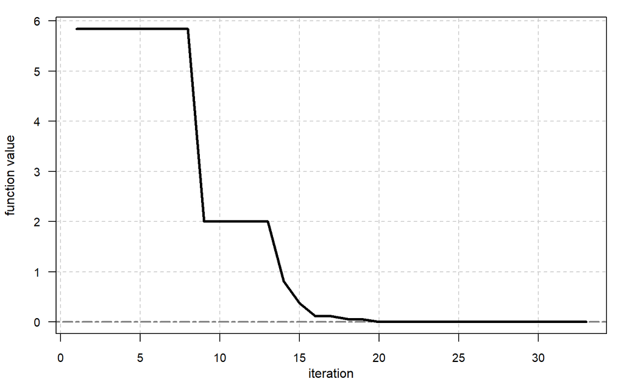

```r
plot(Output)
```

### Plot Kedua

```
## 33 iterations are displayed
```

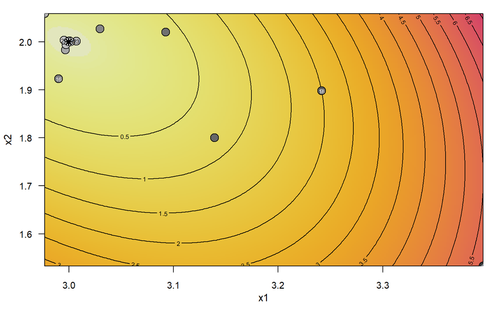

```r
plot(Output, 'contour')
```

## Contoh Ketiga

$f(x_1, x_2, x_3, x_4) = 100(x_1^2 - x_2)^2 + (x_1 - 1)^2 + (x_3-1)^2 +$ $90(x_3^2 - x_4)^2 + 10.1((x_2 - 1)^2 + (x_4 - 1)^2) + 19.8(x_2 - 1)*(x_4-1)$

```r
  co <- function(x){
    x1 <- x[1]
    x2 <- x[2]
    x3 <- x[3]
    x4 <- x[4]

    term1 <- 100 * (x1^2 - x2)^2
    term2 <- (x1 - 1)^2
    term3 <- (x3-1)^2
    term4 <- 90 * (x3^2 - x4)^2
    term5 <- 10.1 * ((x2 - 1)^2 + (x4 - 1)^2)
    term6 <- 19.8 * (x2 - 1)*(x4-1)

     y <- term1 + term2 + term3 + term4 + term5 + term6
  }
```

```r
  optim_nm(co, k = 4)
```

```
## $par
##
## 0.9999040 0.9998368 0.9998313 0.9997856
##
## $function_value
## [1] 2.906124e-06
##
## $trace
## NULL
##
## $fun
## function(x){
##     x1 <- x[1]
##     x2 <- x[2]
##     x3 <- x[3]
##     x4 <- x[4]
##
##     term1 <- 100 * (x1^2 - x2)^2
##     term2 <- (x1 - 1)^2
##     term3 <- (x3-1)^2
##     term4 <- 90 * (x3^2 - x4)^2
##     term5 <- 10.1 * ((x2 - 1)^2 + (x4 - 1)^2)
##     term6 <- 19.8 * (x2 - 1)*(x4-1)
##
##      y <- term1 + term2 + term3 + term4 + term5 + term6
##   }
## <bytecode: 0x000001ff5bb45998>
##
## $start
## [1]  0.5988987 -0.1610542  0.2444116  0.8151857
##
## $upper
## [1] NA
##
## $lower
## [1] NA
##
## $control
## $control$k
## [1] 4
##
## $control$iterations
## [1] 244
##
##
## attr(,"class")
## [1] "optim_nmsa"
```

Pada contoh ini, karena terdiri dari 4 peubah, tidak bisa dikeluarkan plotnya.

Secara default, `optim_nm` akan mengeluarkan nilai minimum. Untuk mengetahui nilai maksimum, Anda bisa menambahkan opsi `maximum = TRUE`

```r
  optim_nm(co, k = 4, maximum = TRUE)
```

```
## $par
##
##  1.076734e+55 -9.921520e+54  9.026605e+54 -1.236283e+54
##
## $function_value
## [1] 1.941609e+222
##
## $trace
## NULL
##
## $fun
## function(x){
##     x1 <- x[1]
##     x2 <- x[2]
##     x3 <- x[3]
##     x4 <- x[4]
##
##     term1 <- 100 * (x1^2 - x2)^2
##     term2 <- (x1 - 1)^2
##     term3 <- (x3-1)^2
##     term4 <- 90 * (x3^2 - x4)^2
##     term5 <- 10.1 * ((x2 - 1)^2 + (x4 - 1)^2)
##     term6 <- 19.8 * (x2 - 1)*(x4-1)
##
##      y <- term1 + term2 + term3 + term4 + term5 + term6
##   }
## <bytecode: 0x000001ff5bb45998>
##
## $start
## [1]  0.36539368  0.78168388 -0.07972715 -0.72248914
##
## $upper
## [1] NA
##
## $lower
## [1] NA
##
## $control
## $control$k
## [1] 4
##
## $control$iterations
## [1] 500
##
##
## attr(,"class")
## [1] "optim_nmsa"
```

Dapat dilihat, bahwa setelah maksimum iterasi (secara default `exit = 500`), nilai belum mencapai maksimum, karena nilai toleransi selisih antar nilai fungsi belum tercapai (secara default `tol = 0.00001`).

## Contoh Keempat

$f(x_1, x_2) = x_1 - x_2 + 2x_1^2 + 2x_1x_2+x_2^2$

```r
G <- function(x){
    x[1] - x[2] + 2*x[1]^2 + 2*x[1]*x[2] + x[2]^2
  }
```

Dengan $\alpha$ = 1.0, $\beta$ = 0.5 dan $\gamma$ = 2.0, dengan $\epsilon$ = 0.2

```r
Output <- optim_nm(fun = G, start = c(5,4), k = 2, trace = TRUE, alpha = 1, beta = 0.5, gamma = 2, tol = 0.2)
```

```r
Output
```

```
## $par
##
## -1.407927  1.834713
##
## $function_value
## [1] -1.078235
##
## $trace
##       iteration function_value       x_1      x_2
##  [1,]         1    107.0000000  5.000000 4.000000
##  [2,]         2     81.0588745  2.171573 6.828427
##  [3,]         3     16.2811123  1.136297 2.964724
##  [4,]         4     12.1963933 -1.692130 5.793151
##  [5,]         5      0.3286919 -1.502662 3.154193
##  [6,]         6      0.3286919 -1.502662 3.154193
##  [7,]         7      0.3286919 -1.502662 3.154193
##  [8,]         8      0.3286919 -1.502662 3.154193
##  [9,]         9     -1.0782349 -1.407927 1.834713
## [10,]        10     -1.0782349 -1.407927 1.834713
##
## $fun
## function(x){
##     x[1] - x[2] + 2*x[1]^2 + 2*x[1]*x[2] + x[2]^2
##   }
## <bytecode: 0x000001ff56c5e5c8>
##
## $start
## [1] 5 4
##
## $upper
## [1] NA
##
## $lower
## [1] NA
##
## $control
## $control$k
## [1] 2
##
## $control$iterations
## [1] 10
##
##
## attr(,"class")
## [1] "optim_nmsa"
```

Secara manual, terdapat pada : Singiresu S. Rao. 2009. Engineering Optimization: Theory and Practice 332-335. Jon Wiley & Sons